# Machine Learning: Pumping Iron

Dan Simerlink

December 21, 2015

## Clear all variables from the work space

```r
rm(list=ls())
```

## Load the relevant libraries

```r
library(caret)
library(data.table)
library(gbm)
library(ggplot2)
library(htmltools)
library(knitrBootstrap)
library(neuralnet)
library(parallel)
library(plyr)
library(randomForest)
library(rattle)
library(RColorBrewer)
library(Rcpp)
library(reshape2)
library(rmarkdown)
library(rpart)
library(rpart.plot)
library(splines)
library(survival)
library(xtable)
```

# Project Overview

Devices such as Jawbone Up, Nike FuelBand, and Fitbit make it possible to inexpensively collect a large amount of data about personal activity. These type of devices are used by a group of enthusiasts who regularly take measurements about themselves to improve their health or to find patterns in their behavior. The goal of this project is to use data from accelerometers on the belt, forearm, arm, and dumbbell. “Six young health participants were asked to perform one set of 10 repetitions of the Unilateral Dumbbell Biceps Curl in five different fashions: exactly according to the specification (Class A), throwing the elbows to the front (Class B), lifting the dumbbell only halfway (Class C), lowering the dumbbell only halfway (Class D) and throwing the hips to the front (Class E).”

In order to predict whether the exercise was done correctly or incorrectly, three machine learning algorithms were tested (decision tress, random forests, and generalized boosted regression). After comparing the accuracy, total out of sample error, and elapsed system time, it was concluded that the random forests machine learning method was the best choice for this data. Also after examining each of the variables, it was determiend that roll_belt, yaw_belt, and pitch_foream were the three most important variables.

Sources: http://groupware.les.inf.puc-rio.br/har https://class.coursera.org/predmachlearn-034/human_grading/view/courses/975204/assessments/4/submissions Velloso, E.; Bulling, A.; Gellersen, H.; Ugulino, W.; Fuks, H. Qualitative Activity Recognition of Weight Lifting Exercises. Proceedings of 4th International Conference in Cooperation with SIGCHI (Augmented Human ’13) . Stuttgart, Germany: ACM SIGCHI, 2013.Read more: http://groupware.les.inf.puc-rio.br/har#ixzz3sQGwpUPF

# Load, Clean, Prepare, and Examine the Data

The data is loaded into a data frame, and is then partitioned, checked for near zero variances, and then visually inspected.

## Load the Data into a Data frame

After the data is loaded into a data frame, the integrity of the data is checked by comparing the column headings of the “trainingData” and the “submit20” data. (The “test” data set was renamed to “submit20” to differentiate it from the testing data) The only difference between the two data frames was found in column #160. Next the unnecessary columns and the columns containing NAs were deleted, which resulted in a reduction from 160 columns to 54 columns.

```r
trainingData <- read.csv("http://d396qusza40orc.cloudfront.net/predmachlearn/pml-training.csv", na.strings=c("NA","#DIV/0!",""))
submit20 <- read.csv("http://d396qusza40orc.cloudfront.net/predmachlearn/pml-testing.csv", na.strings=c("NA","#DIV/0!",""))
#Confirm that the column names of test_data match the column names of submit20
sameName <- colnames(trainingData) == colnames(submit20)
# display the names that don't match
colnames(trainingData)[sameName==FALSE]
colnames(submit20)[sameName==FALSE]

#Delete the unnecesary columns
trainingData2 <- (trainingData[ , c(2, 8:11, 37:49, 60:68, 84:86, 102, 113:124, 140, 151:160)])
submit20_2 <-  (submit20[ , c(2, 8:11, 37:49, 60:68, 84:86, 102, 113:124, 140, 151:160)])
```

## Partition the data, and check for near zero variances

Source: Retrieved 11/14/2015 from http://www.r-bloggers.com/near-zero-variance-predictors-should-we-remove-them/

```r
# Partition the trainingData into 60% training data and 40% testing data.
set.seed(2345)
inTrain <- createDataPartition(y=trainingData2$classe, p=0.6, list=FALSE)
training <- trainingData2[inTrain, ]
testing <- trainingData2[-inTrain, ]

# Check for Nar Zero Variance in the data sets
nzvTraining <- nearZeroVar(training, saveMetrics = TRUE)
#Remove the comment from the following line to print the nzv table
#knitr::kable(nzvTraining, digits = 2, caption = "Near Zero Variances. Training")
nzvTesting <- nearZeroVar(testing, saveMetrics = TRUE)
#Remove the comment from the following line to print the nzv table
#knitr::kable(nzvTesting, digits = 2, caption = "Near Zero Variances. Testing")
```

# Visually Examine the Data

Next, data was visually examined via histograms, and many of the histograms displayed a multi-modal distribution. This is to be expected given that the data includes the use of the correct method, and several uses of the incorrect method.

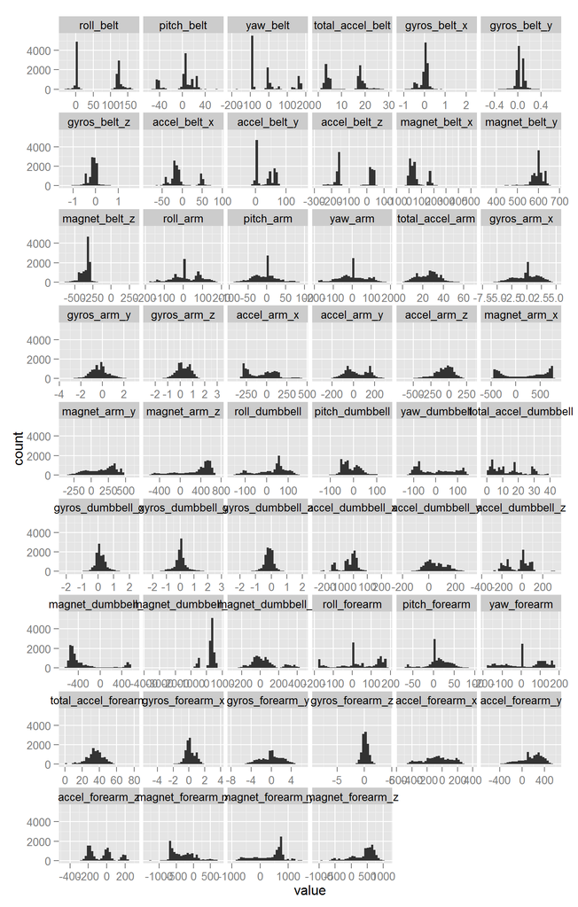

```r
trainBox <- melt(training[,c(2:54)])
ggplot(trainBox,aes(x = value)) +
    facet_wrap(~variable,nrow = 9, ncol = 6, scales = "free_x") +
    geom_histogram()
```

# Train the Machine Learning Model

The training data will be processed via the three machine learning models (decision tress, random forests, and generalized boosted regression). Each of these three machine learning models uses a different approach; short explanations of each approach are included at the beginning of the relevant section.

## Decision Trees

In this section, the decision trees are visually depicted, and then a confusion matrix is created to determine the accuracy of the machine learning model. “Decision trees classify instances by sorting them down the tree from the root to some leaf node. Each node in the tree specifies a test of some attribute of the instance and each branch descending from the node corresponds to one of the possible values for this attribute.”

Source: Retrieved on 11/30/2015 from http://www.cs.princeton.edu/courses/archive/spr07/cos424/papers/mitchell-dectrees.pdf

[figure not shown]

```r
set.seed(2345)
decisionTreeTrain <- rpart(classe ~ ., data=training, method = "class")
fancyRpartPlot(decisionTreeTrain)
```

```r
#Create Confusion Matrix
predictionsDecisionTreeTrain <- predict(decisionTreeTrain, training, type = "class")
decisionTreeConfusionMatrixTrain <- confusionMatrix(predictionsDecisionTreeTrain, training$classe)
decisionTreeConfusionMatrixTrain
```

```
## Confusion Matrix and Statistics
##
##           Reference
## Prediction    A    B    C    D    E
##          A 3063  367  110  210   43
##          B   99 1447  167  170  192
##          C   81  218 1593  187  172
##          D   80  141  154 1180  146
##          E   25  106   30  183 1612
##
## Overall Statistics
##
##                Accuracy : 0.7553
##                  95% CI : (0.7475, 0.7631)
##     No Information Rate : 0.2843
##     P-Value [Acc > NIR] : < 2.2e-16
##
##                   Kappa : 0.689
##  Mcnemar's Test P-Value : < 2.2e-16
##
## Statistics by Class:
##
##                      Class: A Class: B Class: C Class: D Class: E
## Sensitivity            0.9149   0.6349   0.7756   0.6114   0.7446
## Specificity            0.9134   0.9339   0.9323   0.9471   0.9642
## Pos Pred Value         0.8075   0.6973   0.7077   0.6937   0.8241
## Neg Pred Value         0.9643   0.9142   0.9516   0.9256   0.9437
## Prevalence             0.2843   0.1935   0.1744   0.1639   0.1838
## Detection Rate         0.2601   0.1229   0.1353   0.1002   0.1369
## Detection Prevalence   0.3221   0.1762   0.1912   0.1444   0.1661
## Balanced Accuracy      0.9141   0.7844   0.8539   0.7792   0.8544
```

## Random Forest

The random forest model is visually depicted, and then a confusion matrix is created to determine the accuracy of this machine learning model. “The random forest starts with a standard machine learning technique called a”decision tree“…In a decision tree, an input is entered at the top and as it traverses down the tree the data gets bucketed into smaller and smaller sets…[One strength is that] random forest run times are quite fast, and they are able to deal with unbalanced and missing data. Random Forest weaknesses are that when used for regression they cannot predict beyond the range in the training data, and that they may over-fit data sets that are particularly noisy.” Note: To avoid overfitting the data using random forests, see http://stats.stackexchange.com/questions/111968/random-forest-how-to-handle-overfitting

Source: Retrieved 11/30/2015 from https://citizennet.com/blog/2012/11/10/random-forests-ensembles-and-performance-metrics/

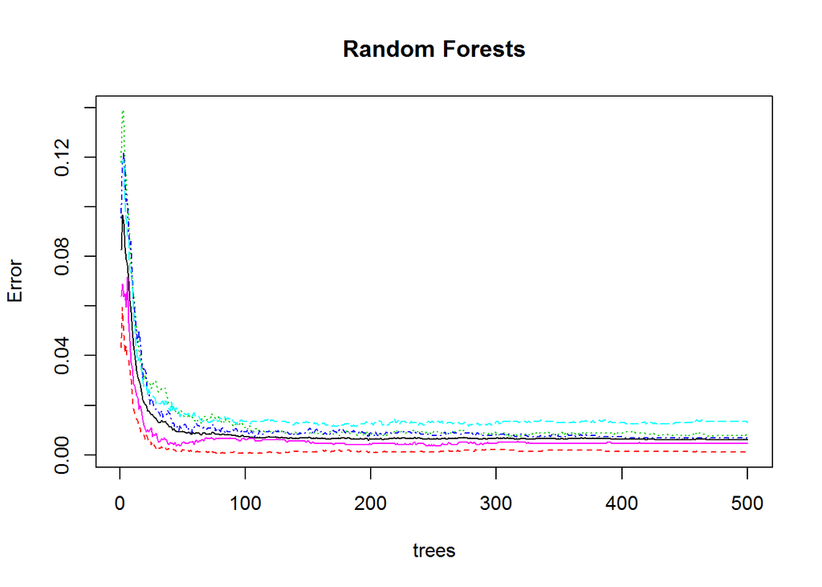

```r
set.seed(2345)
randomForestTrain <- randomForest(classe ~ ., data=training)
predictions_ranfor_train <- predict(randomForestTrain, type = "class")
randomForestConfusionMatrixTrain <- confusionMatrix(predictions_ranfor_train, training$classe)

plot(randomForestTrain, main = "")
title(main="Random Forests")
```

```r
randomForestConfusionMatrixTrain
```

```
## Confusion Matrix and Statistics
##
##           Reference
## Prediction    A    B    C    D    E
##          A 3344   14    0    0    0
##          B    2 2260   12    0    0
##          C    2    5 2040   23    1
##          D    0    0    2 1905    9
##          E    0    0    0    2 2155
##
## Overall Statistics
##
##                Accuracy : 0.9939
##                  95% CI : (0.9923, 0.9952)
##     No Information Rate : 0.2843
##     P-Value [Acc > NIR] : < 2.2e-16
##
##                   Kappa : 0.9923
##  Mcnemar's Test P-Value : NA
##
## Statistics by Class:
##
##                      Class: A Class: B Class: C Class: D Class: E
## Sensitivity            0.9988   0.9917   0.9932   0.9870   0.9954
## Specificity            0.9983   0.9985   0.9968   0.9989   0.9998
## Pos Pred Value         0.9958   0.9938   0.9850   0.9943   0.9991
## Neg Pred Value         0.9995   0.9980   0.9986   0.9975   0.9990
## Prevalence             0.2843   0.1935   0.1744   0.1639   0.1838
## Detection Rate         0.2840   0.1919   0.1732   0.1618   0.1830
## Detection Prevalence   0.2852   0.1931   0.1759   0.1627   0.1832
## Balanced Accuracy      0.9986   0.9951   0.9950   0.9930   0.9976
```

## Generalized Boosted Regression

The Generalized Boosted Regression (GBR) model is visually depicted, and then a confusion matrix is created to determine the accuracy of this machine learning model. “[In] GBMs, the learning procedure consecutively fits new models to provide a more accurate estimate of the response variable…Includes regression methods for least squares, absolute loss, logistic, Poisson etc…”

Sources:

Retrieved on 11/30/2015 from http://www.ncbi.nlm.nih.gov/pmc/articles/PMC3885826/

Retrieved on 11/30/2015 from https://cran.r-project.org/web/packages/gbm/gbm.pdf

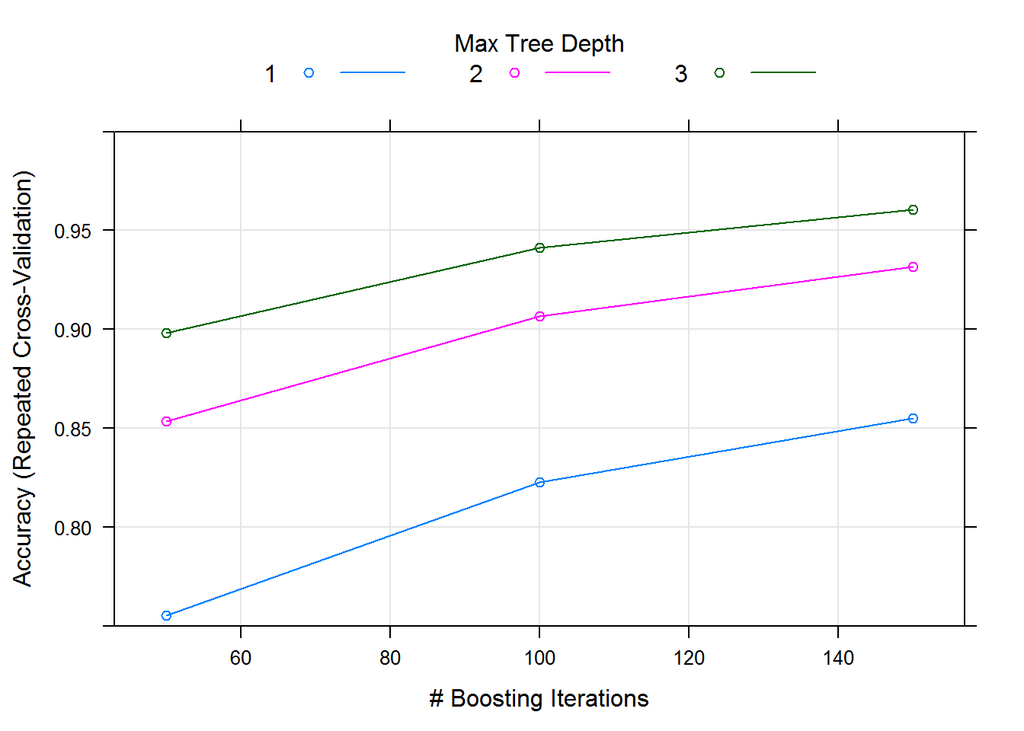

```r
set.seed(2345)
gbrControlTrain <- trainControl(method = "repeatedcv", number = 5,repeats = 1)
gbmFit1Train <- train(classe ~ ., data=training, method = "gbm", trControl = gbrControlTrain, verbose = FALSE)
gbmFinalModel1Train  <- gbmFit1Train$finalModel
gbmPredictionTrain <- predict(gbmFit1Train, newdata=training)
gbmConfusionMatrixTrain <- confusionMatrix(gbmPredictionTrain, training$classe)

par(mar = rep(2, 4))
plot(gbmFit1Train, ylim=c(0.75, 1))
```

```r
gbmConfusionMatrixTrain
```

```
## Confusion Matrix and Statistics
##
##           Reference
## Prediction    A    B    C    D    E
##          A 3317   53    0    1    3
##          B   22 2187   43    4   13
##          C    3   37 1991   45   11
##          D    5    1   19 1867   26
##          E    1    1    1   13 2112
##
## Overall Statistics
##
##                Accuracy : 0.9744
##                  95% CI : (0.9713, 0.9771)
##     No Information Rate : 0.2843
##     P-Value [Acc > NIR] : < 2.2e-16
##
##                   Kappa : 0.9676
##  Mcnemar's Test P-Value : 2.842e-08
##
## Statistics by Class:
##
##                      Class: A Class: B Class: C Class: D Class: E
## Sensitivity            0.9907   0.9596   0.9693   0.9674   0.9755
## Specificity            0.9932   0.9914   0.9901   0.9948   0.9983
## Pos Pred Value         0.9831   0.9639   0.9540   0.9734   0.9925
## Neg Pred Value         0.9963   0.9903   0.9935   0.9936   0.9945
## Prevalence             0.2843   0.1935   0.1744   0.1639   0.1838
## Detection Rate         0.2817   0.1857   0.1691   0.1585   0.1793
## Detection Prevalence   0.2865   0.1927   0.1772   0.1629   0.1807
## Balanced Accuracy      0.9920   0.9755   0.9797   0.9811   0.9869
```

# Test the Machine Learning Models

## Decision Trees

```r
set.seed(2345)
decisionTreeTest <- rpart(classe ~ ., data=testing, method = "class")
#Create Confusion Matrix
predictionsDecisionTreeTest <- predict(decisionTreeTest, testing, type = "class")
decisionTreeConfusionMatrixTest <- confusionMatrix(predictionsDecisionTreeTest, testing$classe)
decisionTreeConfusionMatrixTest
```

```
## Confusion Matrix and Statistics
##
##           Reference
## Prediction    A    B    C    D    E
##          A 1978  276   33   74   52
##          B   83  859   63  101  121
##          C   48  173 1103  172  132
##          D   82  108   91  827   75
##          E   41  102   78  112 1062
##
## Overall Statistics
##
##                Accuracy : 0.7429
##                  95% CI : (0.7331, 0.7526)
##     No Information Rate : 0.2845
##     P-Value [Acc > NIR] : < 2.2e-16
##
##                   Kappa : 0.674
##  Mcnemar's Test P-Value : < 2.2e-16
##
## Statistics by Class:
##
##                      Class: A Class: B Class: C Class: D Class: E
## Sensitivity            0.8862   0.5659   0.8063   0.6431   0.7365
## Specificity            0.9225   0.9418   0.9190   0.9457   0.9480
## Pos Pred Value         0.8197   0.7001   0.6775   0.6991   0.7613
## Neg Pred Value         0.9532   0.9004   0.9574   0.9311   0.9411
## Prevalence             0.2845   0.1935   0.1744   0.1639   0.1838
## Detection Rate         0.2521   0.1095   0.1406   0.1054   0.1354
## Detection Prevalence   0.3075   0.1564   0.2075   0.1508   0.1778
## Balanced Accuracy      0.9044   0.7539   0.8626   0.7944   0.8422
```

## Random Forests

```r
set.seed(2345)
randomForestTest <- randomForest(classe ~ ., data=testing)
predictionsRandomForestTest <- predict(randomForestTest, type = "class")
randomForestConfusionMatrixTest <- confusionMatrix(predictionsRandomForestTest, testing$classe)
randomForestConfusionMatrixTest
```

```
## Confusion Matrix and Statistics
##
##           Reference
## Prediction    A    B    C    D    E
##          A 2227   17    0    0    0
##          B    3 1489   15    0    0
##          C    0   11 1348   28    3
##          D    0    1    5 1257    4
##          E    2    0    0    1 1435
##
## Overall Statistics
##
##                Accuracy : 0.9885
##                  95% CI : (0.9859, 0.9908)
##     No Information Rate : 0.2845
##     P-Value [Acc > NIR] : < 2.2e-16
##
##                   Kappa : 0.9855
##  Mcnemar's Test P-Value : NA
##
## Statistics by Class:
##
##                      Class: A Class: B Class: C Class: D Class: E
## Sensitivity            0.9978   0.9809   0.9854   0.9774   0.9951
## Specificity            0.9970   0.9972   0.9935   0.9985   0.9995
## Pos Pred Value         0.9924   0.9881   0.9698   0.9921   0.9979
## Neg Pred Value         0.9991   0.9954   0.9969   0.9956   0.9989
## Prevalence             0.2845   0.1935   0.1744   0.1639   0.1838
## Detection Rate         0.2838   0.1898   0.1718   0.1602   0.1829
## Detection Prevalence   0.2860   0.1921   0.1772   0.1615   0.1833
## Balanced Accuracy      0.9974   0.9890   0.9894   0.9880   0.9973
```

## Generalized Boosted Regression

```r
set.seed(2345)
gbrControlTest <- trainControl(method = "repeatedcv", number = 5,repeats = 1)
gbmFit1Test <- train(classe ~ ., data=testing, method = "gbm", trControl = gbrControlTest, verbose = FALSE)
gbmFinalModel1Test <- gbmFit1Test$finalModel
gbmPredictionTest <- predict(gbmFit1Test, newdata=testing)
gbmConfusionMatrixTest <- confusionMatrix(gbmPredictionTest, testing$classe)
gbmConfusionMatrixTest
```

```
## Confusion Matrix and Statistics
##
##           Reference
## Prediction    A    B    C    D    E
##          A 2213   30    0    0    2
##          B   13 1467   18    0    7
##          C    3   21 1341   31    8
##          D    1    0    7 1253   11
##          E    2    0    2    2 1414
##
## Overall Statistics
##
##                Accuracy : 0.9799
##                  95% CI : (0.9765, 0.9829)
##     No Information Rate : 0.2845
##     P-Value [Acc > NIR] : < 2.2e-16
##
##                   Kappa : 0.9745
##  Mcnemar's Test P-Value : NA
##
## Statistics by Class:
##
##                      Class: A Class: B Class: C Class: D Class: E
## Sensitivity            0.9915   0.9664   0.9803   0.9743   0.9806
## Specificity            0.9943   0.9940   0.9903   0.9971   0.9991
## Pos Pred Value         0.9857   0.9748   0.9551   0.9851   0.9958
## Neg Pred Value         0.9966   0.9920   0.9958   0.9950   0.9956
## Prevalence             0.2845   0.1935   0.1744   0.1639   0.1838
## Detection Rate         0.2821   0.1870   0.1709   0.1597   0.1802
## Detection Prevalence   0.2861   0.1918   0.1789   0.1621   0.1810
## Balanced Accuracy      0.9929   0.9802   0.9853   0.9857   0.9898
```

```r
#gbmConfusionMatrixTest$overall
```

# Compare the Machine Learning Algorithms

```r
row1 <- c("Training Accuracy", decisionTreeConfusionMatrixTrain$overall[1], randomForestConfusionMatrixTrain$overall[1], gbmConfusionMatrixTrain$overall[1])
row2 <- c("Testing Accuracy",decisionTreeConfusionMatrixTest$overall[1], randomForestConfusionMatrixTest$overall[1], gbmConfusionMatrixTest$overall[1])
row3 <- c("Total Out of Sample Error", (1-((decisionTreeConfusionMatrixTrain$overall[1]+decisionTreeConfusionMatrixTest$overall[1])/2)), (1-((randomForestConfusionMatrixTrain$overall[1]+randomForestConfusionMatrixTest$overall[1])/2)), (1-((gbmConfusionMatrixTrain$overall[1]+gbmConfusionMatrixTest$overall[1])/2)))
#Calculate Elapsed System Time for "Test" to Determine the Speed of Execution
systemTimeDecisionTreeConfusionMatrixTest <- system.time( replicate(100000, decisionTreeConfusionMatrixTest))
systemTimeRandomForestConfusionMatrixTest <- system.time( replicate(100000, randomForestConfusionMatrixTest))
systemTimeGbmConfusionMatrixTest <- system.time( replicate(100000, gbmConfusionMatrixTest))
row4 <- c("Elapsed System Time for Test", (systemTimeDecisionTreeConfusionMatrixTest[3]), (systemTimeRandomForestConfusionMatrixTest[3]), (systemTimeGbmConfusionMatrixTest[3]))

Accuracy <- as.data.frame(rbind(row1, row2, row3, row4))
names(Accuracy) <- c("", "Decision Trees", "Random Forests","Generalized Boosted Regression")
knitr::kable(Accuracy, row.names=FALSE, caption = "Accuracy")
```

Accuracy

|  | Decision Trees | Random Forests | Generalized Boosted Regression |
| --- | --- | --- | --- |
| Training Accuracy | 0.755349864130435 | 0.993885869565217 | 0.974354619565217 |
| Testing Accuracy | 0.742926331888861 | 0.988529186846801 | 0.979862350242162 |
| Total Out of Sample Error | 0.250861901990352 | 0.0087924717939909 | 0.0228915150963105 |
| Elapsed System Time for Test | 0.420000000000073 | 0.419999999999959 | 0.400000000000091 |

# Determine the Important Variables

The data used for this study contained many variables, and the following graph and table depict the most important ones. The importance was ranked using the “wrappers around the importance functions from the randomForest and party packages, respectively. Partial Least Squares (PLS): the variable importance measure here is based on weighted sums of the absolute regression coefficients. The weights are a function of the reduction of the sums of squares across the number of PLS components and are computed separately for each outcome. Therefore, the contribution of the coefficients are weighted proportionally to the reduction in the sums of squares. Recursive Partitioning: The reduction in the loss function (e.g. mean squared error) attributed to each variable at each split is tabulated and the sum is returned. Also, since there may be candidate variables that are important but are not used in a split, the top competing variables are also tabulated at each split.”

Source: Retrieved 11/30/2015 from http://www.inside-r.org/packages/cran/caret/docs/varimp

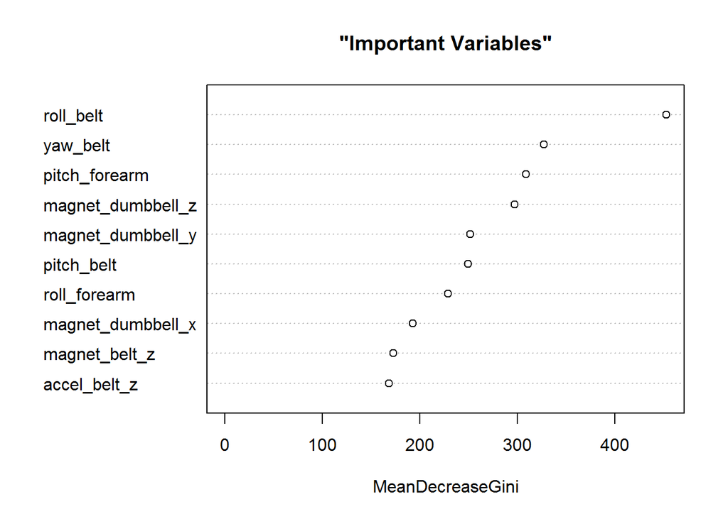

```r
varImpPlot(randomForestTest, sort=TRUE, n.var=min(10, nrow(randomForestTest$importance)),
           type=NULL, class=NULL, scale=TRUE,
           main=deparse(substitute("Important Variables")))
```

```r
#class(randomForestTest)
randomForestImportance <- varImp(randomForestTest, by.tree=FALSE, count=TRUE, sort.default(randomForestTest$Overall, decreasing = FALSE))
randomForestImportance$max <- apply(randomForestImportance, 1, max)
randomForestImportanceSorted <- randomForestImportance[order(-randomForestImportance$max),]
knitr::kable(randomForestImportanceSorted, row.names=TRUE)
```

|  | Overall | max |
| --- | --- | --- |
| roll_belt | 452.78736 | 452.78736 |
| yaw_belt | 326.96477 | 326.96477 |
| pitch_forearm | 308.59507 | 308.59507 |
| magnet_dumbbell_z | 297.06994 | 297.06994 |
| magnet_dumbbell_y | 251.65708 | 251.65708 |
| pitch_belt | 249.13503 | 249.13503 |
| roll_forearm | 228.70407 | 228.70407 |
| magnet_dumbbell_x | 192.94638 | 192.94638 |
| magnet_belt_z | 172.88731 | 172.88731 |
| accel_belt_z | 168.44527 | 168.44527 |
| roll_dumbbell | 167.10358 | 167.10358 |
| accel_dumbbell_y | 166.93704 | 166.93704 |
| magnet_belt_y | 165.92849 | 165.92849 |
| accel_dumbbell_z | 134.53308 | 134.53308 |
| accel_forearm_x | 134.19190 | 134.19190 |
| roll_arm | 133.41673 | 133.41673 |
| gyros_belt_z | 132.51816 | 132.51816 |
| magnet_forearm_z | 113.34885 | 113.34885 |
| gyros_dumbbell_y | 108.59646 | 108.59646 |
| total_accel_dumbbell | 104.07599 | 104.07599 |
| magnet_arm_x | 102.93131 | 102.93131 |
| yaw_dumbbell | 101.91324 | 101.91324 |
| accel_dumbbell_x | 101.71586 | 101.71586 |
| magnet_belt_x | 100.91244 | 100.91244 |
| accel_forearm_z | 96.49691 | 96.49691 |
| accel_arm_x | 94.10717 | 94.10717 |
| magnet_arm_y | 93.40184 | 93.40184 |
| yaw_arm | 92.39071 | 92.39071 |
| magnet_forearm_y | 92.12267 | 92.12267 |
| magnet_forearm_x | 87.39566 | 87.39566 |
| pitch_dumbbell | 77.58576 | 77.58576 |
| total_accel_belt | 77.19176 | 77.19176 |
| magnet_arm_z | 72.23261 | 72.23261 |
| pitch_arm | 71.88096 | 71.88096 |
| yaw_forearm | 64.83481 | 64.83481 |
| accel_arm_y | 59.66744 | 59.66744 |
| gyros_arm_x | 57.81386 | 57.81386 |
| accel_forearm_y | 56.59522 | 56.59522 |
| gyros_arm_y | 56.59470 | 56.59470 |
| user_name | 55.99211 | 55.99211 |
| accel_belt_y | 55.46532 | 55.46532 |
| gyros_dumbbell_x | 54.51911 | 54.51911 |
| accel_arm_z | 52.29199 | 52.29199 |
| accel_belt_x | 51.23530 | 51.23530 |
| gyros_forearm_y | 50.98519 | 50.98519 |
| total_accel_forearm | 46.37985 | 46.37985 |
| gyros_belt_y | 45.67161 | 45.67161 |
| total_accel_arm | 43.21659 | 43.21659 |
| gyros_belt_x | 38.51302 | 38.51302 |
| gyros_forearm_z | 38.41945 | 38.41945 |
| gyros_dumbbell_z | 38.30603 | 38.30603 |
| gyros_forearm_x | 35.46435 | 35.46435 |
| gyros_arm_z | 27.93150 | 27.93150 |